# Presentation Script

### Introduction

The Royal Society for the Prevention of Cruelty to Animals, or RSPCA, is Australia’s oldest, largest and most trusted animal welfare organisation. In the year of 2018 alone they received over 130,000 animals into their shelters and adoption centres across the country. Through hard work and concerted efforts, they have managed to increase their rates of adoption and reclaiming, improving the outcomes for hundreds of thousands of cats and dogs, who have either been reunited with their owners or have found a new home.

In this presentation, I will answer questions that the RSPCA has asked for the purposes of gaining more insight into the animals, especially the cats and dogs, of Australia. This will help them make more informed decisions in the future through the power of data, with the goal of further increasing their rates of adoption and reclaiming. I believe my analysis will help the RSPCA move forward in their goal and improve animal welfare across Australia as a whole.

### The Data

For this project, I was given three sources of data. The first is from the open RSPCA database and covers Australia as a whole, divided into regions. It looks at the outcomes for cats, dogs and other animals the RSPCA has received into its care (i.e, whether they were rehomed, euthanised, still in stock and so on), with data spanning from 1999 to 2018. The data is from a trusted source and is of high quality.

Here is a map of Australian states for reference:

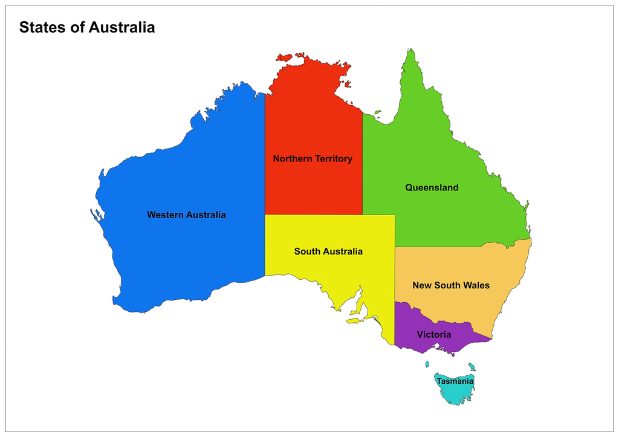

The next two sources I was given concern data specific to Townsville and Brisbane, two large Australian cities.

Townsville is a city on the north-eastern coast of Queensland, Australia. With a population of 180,000, it is the largest settlement in North Queensland; it is unofficially considered the capital of North Queensland.

Brisbane is the official capital of Queensland, and is about 1000km South East of Townsville, in the centre of South East Queensland. It’s population is about 2.6 million. Both datasets consists of data gathered by their respective councils, and concern the volume and type of animal complaints received overtime. This is further broken by suburb. Both these datasets come from local councils and are trusted sources. Here’s another map showing the location of both of these cities:

[figure not shown]

Townsville to Brisbane

### Business Questions

Here are the business questions I have been tasked with investigating:

How have the outcomes for different types of animal changed over time? Are there any major differences between the way different States of Australia deal with animals? Are there any anomalies in the data?

Total call volume for complaint calls: How has this trended over time? Is there a particular animal being called about the most? Do particular suburbs have different type of complaint calls? Do they call about different animals?

Business Intelligence – using the insights you have found, can you predict how this might look for the upcoming year?

### Analysis

So let’s move onto the analysis, and began answering the business questions.

## Total call volume for complaint calls: How has this trended over time?

First, I looked at the total call volume for complaint calls, to see how this trended over time.

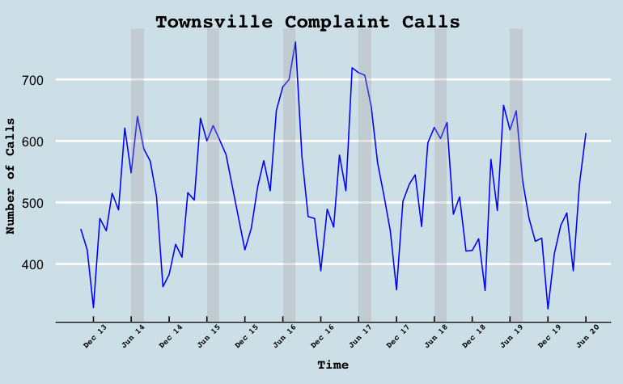

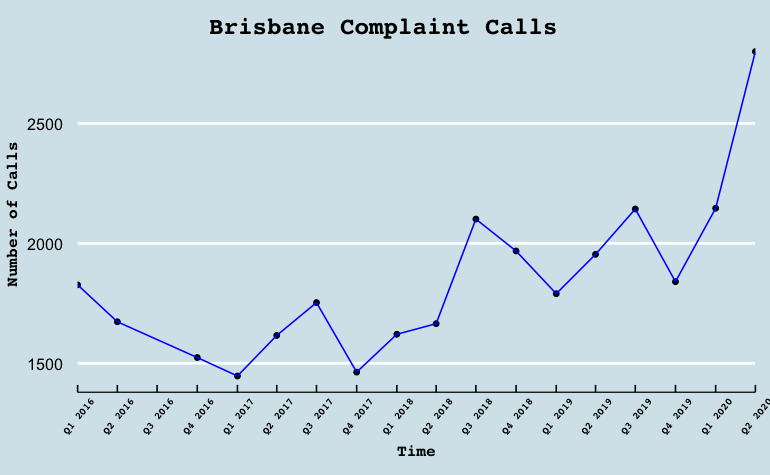

As you can see looking at these graphs, there is a noticeable seasonality. This can clearly be seen in the Townsville graph, with calls peaking around July/August, which is winter for Australia. For Brisbane, which is broken down by quarter rather than month, there does appear to be seasonality but it is less pronounced and we do not have enough data to say this definitively.

So there is evidence of seasonality, but I was also interested to investigate the average overtime in general. Here is some graphs which show this:

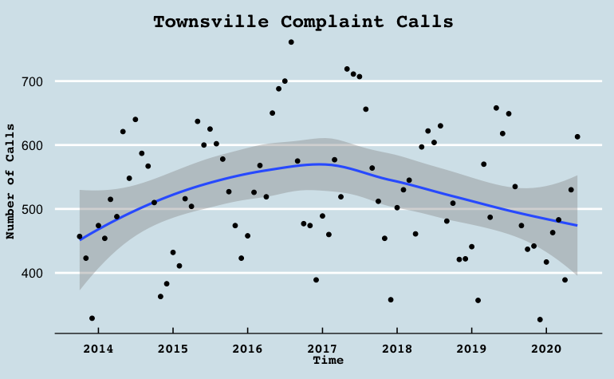

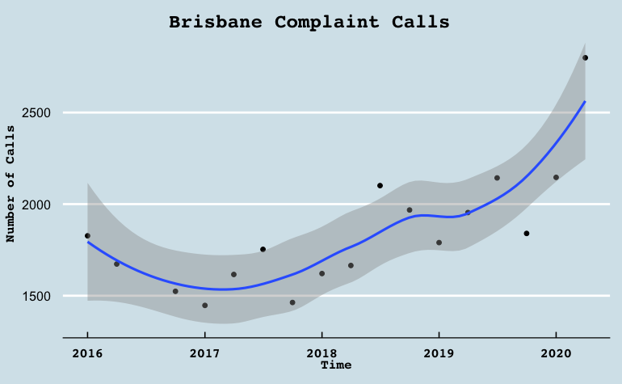

With these graphs, we can see more clearly the general trend, ignoring seasonality. For Townsville, there is a steady increase up to 2017 and then a steady decline, to a similar place to where the number of calls started.

For Brisbane, we can see a more clear trend upward over time, though there is only 4 years of data. This means any conclusions to be drawn from this should be taken with a grain of salt.

## Is there a particular animal being called about the most?

Next, I looked at which animals were being called about the most. Again, I looked at both cities, and this time the conclusion was much more clear.

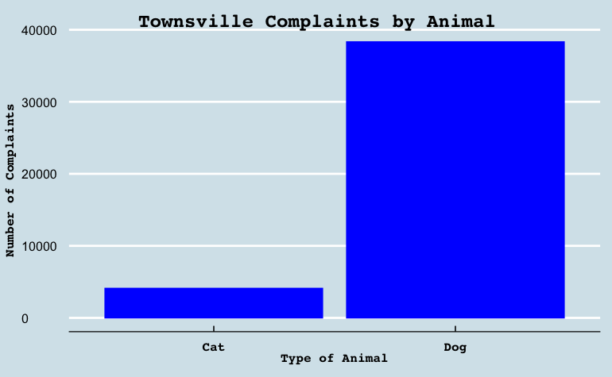

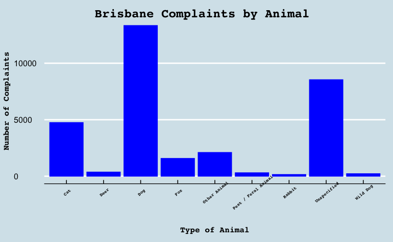

For Townsville, dogs are responsible for 10x the amount of calls as cats!

One interesting point is that the numbers for foxes are quite high for a wild animal. This is something that needs further investigation to learn more about.

## Do particular suburbs have different type of complaint calls? Do they call about different animals?

Now we will look at the data broken down by suburb and complaint type. This proved a little more difficult than one might first think. Brisbane has 192 suburbs, while Townsville has 85. I decided to focus my efforts on the Townsville data, and distill the suburbs down to a more reasonable number. I wanted to look at suburbs with a similar amount of complaint calls. I focused on those with less than 500 and more than 100 calls. I decided that any suburb with less than 100 calls would be such a small number my percentages would be skewed, and no valid conclusions could be drawn.

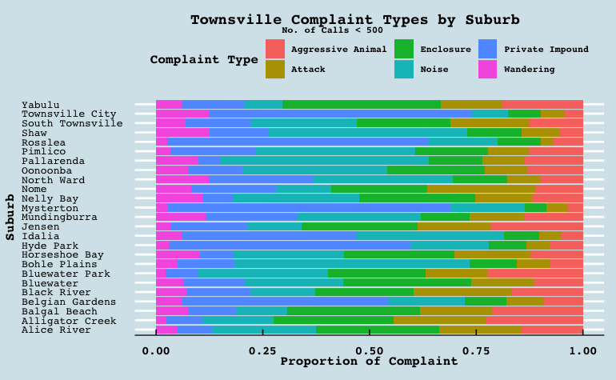

So, here I have shown the relative percentages of complaint types for the suburbs. The data has been scaled, so that a suburb with a higher count doesn’t skew the data, and we can see proportions.

Looking at the same but in a different way, we get:

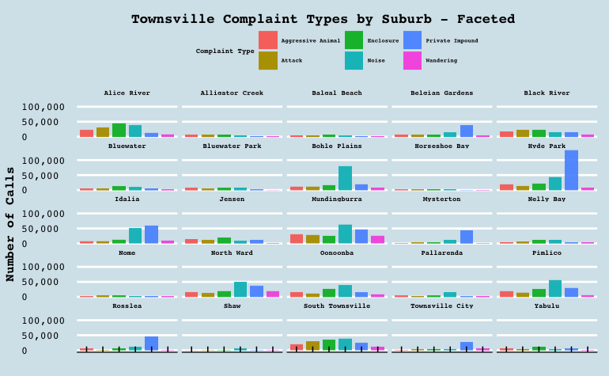

This graph shows the same thing as before but with counts rather than proportions. It allows us to see things in a different way. For example, we can see that Hyde Park has a disproportionate amount of private impounds, while Bohle plains has more noise complaints. This is consistent with the previous graph that showed us proportions, so we can be assured that our analysis is accurate

Looking at another subset of suburbs, this time those with total calls between 500 and 4000, we get this:

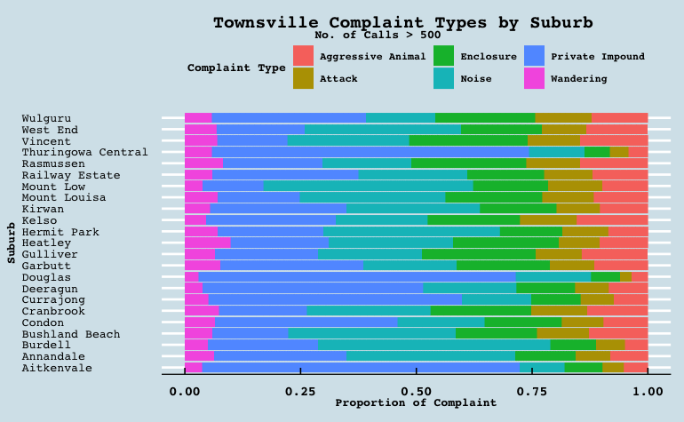

What sticks out to me in these busier suburbs, is the variability in private impounds. Aitkenvale, Thuringowa Central and Douglas stand out as being proportionally very high in number of private impounds. More investigation is needed to find out the cause of this.

Now let’s look at things broken down by type of animal, rather than complaint type. Looking at the original set of suburbs, we get this:

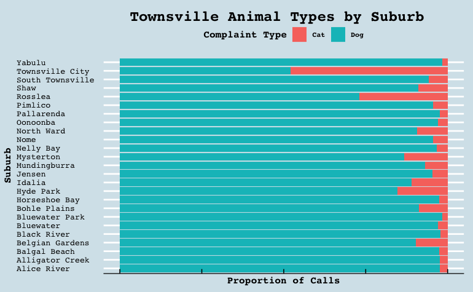

Most suburbs have pretty much the same ratios of cats to dogs, except for Townsville City. This has close to 50:50 ratio, which is unprecedented for this data, and not seen in any other Townsville suburb (I checked even the other groups). This is the only suburb where this is the case. This could potentially indicate a large number of stray cats, but more investigation is needed to see why this is the case.

## How have the outcomes for different types of animal changed over time?

So for this, I decided to look at the outcomes for different animals across time.

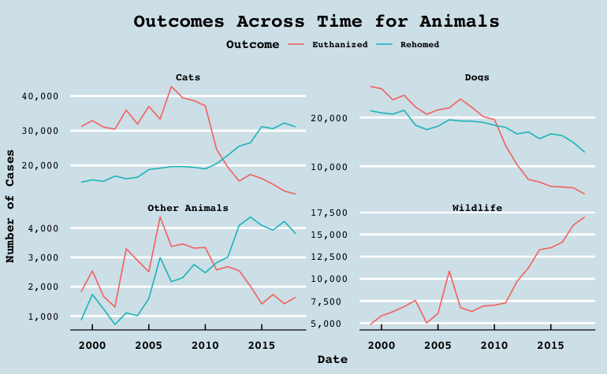

As you can see here, there’s some noticeable trends. The euthanizations have gone way up for wildlife! Looking into this further, I discovered Queensland was responsible for this trend. They have steadily been increasing euthanizations of wildlife overtime, while for other regions this hasn’t been the case at all. Why this is the case is something I recommend the RSCPA look into more.

Another thing to note is the steady decline in euthanizations for everything else. For Other Animals as well as for cats, there is a trend of euthanizations going down and rehoming going up. This is good news and means that the RSPCA is accomplishing it’s goal.

For Dogs, the trend is not so clear, it appears rehoming is on the decline; however euthanizations have fallen dramatically and this is definitely a good sign.

## Are there any major differences between the way different States of Australia deal with animals?

Next, I broke things down by region and looked at the rates of reclaim. For the sake of simplicity, we’ll look at three of Australia’s regions.

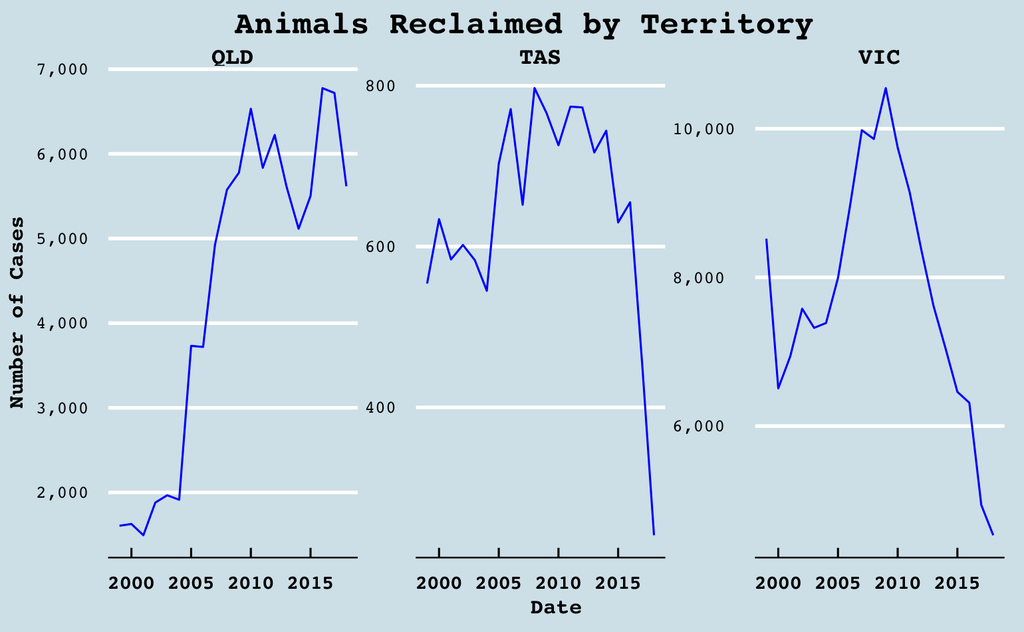

So some interesting things here. Queensland has been steadily climbing, and this speaks well to the RSPCA’s efforts. Victoria, has had quite a bit of variability, but as you can see has been on the decline since about 2009. And Tasmania has had a steep decline since about 2016. This suggests to me that more initiatives and resources might need to be spent on Victoria.

## Are there any anomalies in the data?

There are a few actually, but there is one I will focus on.

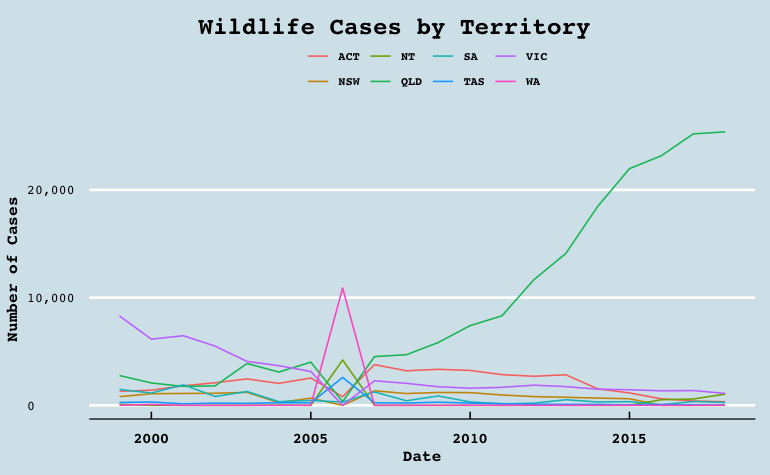

As you can see Western Australia had a huge spike in wildlife in 2006. Given that Western Australia normally accounts for a much smaller number of cases, this is quite stark. Upon further investigation, I discovered that in March 2006, cyclone Emma (a tropical storm) swept over Western Australia. Though a weak storm, the rainfall caused mass flooding. It’s very possible that this is the reason for the proportionally large spike in wildlife cases. This also lead to a spike in euthanasia, as unfortunately for wild animals this is often a necessary course of action.

## Business Intelligence – using the insights you have found, can you predict how this might look for the upcoming year?

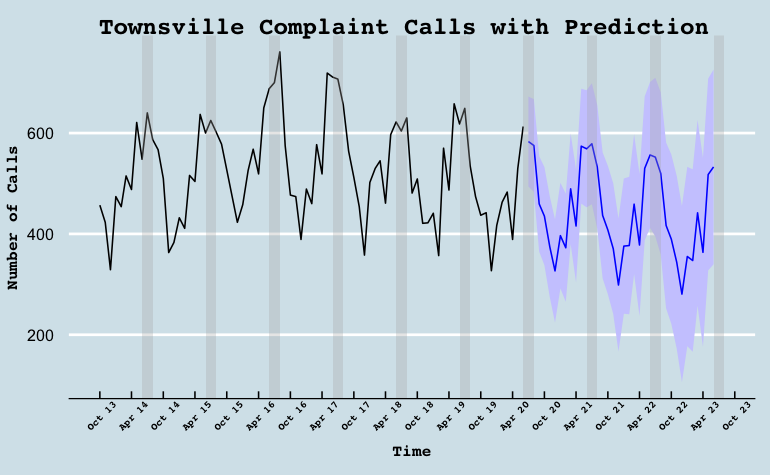

```r
forecast_1 %>%
  filter(.model == "arima") %>%
  autoplot(animal_complaints_tsibble, level = 95) +
  scale_x_yearmonth(date_breaks = "6 months", date_labels = "%b %y") +
  labs(title = "Townsville Complaint Calls with Prediction",
       x = "Time",
       y = "Number of Calls") +
  theme_economist() +
  theme(axis.text.x = element_text(angle = 45, vjust = 1, family = "mono", face = "bold", size = 7),
        #axis.ticks.x =
        axis.title.y = element_text(vjust = 3.2),
        title = element_text(family = "mono", face = "bold"),
        plot.title = element_text(hjust = 0.4),
        legend.title = element_blank(),
        legend.position = "none") +
        annotate("rect", xmin = as.Date("2014-06-01"), xmax = as.Date("2014-08-01"), ymin = -Inf, ymax = Inf, fill = "gray70", alpha = 0.3) +
        annotate("rect", xmin = as.Date("2015-06-01"), xmax = as.Date("2015-08-01"), ymin = -Inf, ymax = Inf, fill = "gray70", alpha = 0.3) +
        annotate("rect", xmin = as.Date("2016-06-01"), xmax = as.Date("2016-08-01"), ymin = -Inf, ymax = Inf, fill = "gray70", alpha = 0.3) +
        annotate("rect", xmin = as.Date("2017-06-01"), xmax = as.Date("2017-08-01"), ymin = -Inf, ymax = Inf, fill = "gray70", alpha = 0.3) +
        annotate("rect", xmin = as.Date("2018-06-01"), xmax = as.Date("2018-08-01"), ymin = -Inf, ymax = Inf, fill = "gray70", alpha = 0.3) +
        annotate("rect", xmin = as.Date("2019-06-01"), xmax = as.Date("2019-08-01"), ymin = -Inf, ymax = Inf, fill = "gray70", alpha = 0.3) +
        annotate("rect", xmin = as.Date("2020-06-01"), xmax = as.Date("2020-08-01"), ymin = -Inf, ymax = Inf, fill = "gray70", alpha = 0.3) +
        annotate("rect", xmin = as.Date("2021-06-01"), xmax = as.Date("2021-08-01"), ymin = -Inf, ymax = Inf, fill = "gray70", alpha = 0.3) +
        annotate("rect", xmin = as.Date("2022-06-01"), xmax = as.Date("2022-08-01"), ymin = -Inf, ymax = Inf, fill = "gray70", alpha = 0.3) +
        annotate("rect", xmin = as.Date("2023-06-01"), xmax = as.Date("2023-08-01"), ymin = -Inf, ymax = Inf, fill = "gray70", alpha = 0.3)
```

So I was also tasked with creating a model, to predict how things might look for the next few years. I focused specifically on the Townsville data, as this was most suitable for forecasting. I used something called the “ARIMA” model, the inner workings of which are quite complicated, but basically it predicts the future based on the past, and is quite good when it comes to seasonal data like I have here. The blue line is the prediction, and the light blue area you see highlighted around it is the confidence interval. Think of this like a margin of error, and it basically means that 95% of the time, our model will predict results in this area.

This model suggests that roughly the same pattern will continue as before, with fairly steady volume of calls and high peaks in Winter. But bear in mind this model is quite limited and shouldn’t be taken as fact; for example, it doesn’t take into account natural disasters and other events which could cause an increase in complaint calls.

## Conclusion

The RSPCA and local councils have got good, quality rich data that have shown some interesting trends over time broken down by region and areas.

My initial analysis has confirmed some interesting trends, some of which indicate good progress towards the RSPCA’s stated goals; for example, euthanizations trending downwards in certain species.

Further investigation with the RSPCA would allow more detailed analysis in the areas that they’re interested in, and allow them to make better informed business decisions.